# Working with RStudio in CDAP

20/10/2022

## About this guide

### Who is this guide for?

This guide is aimed at users who are familiar with R and RStudio, but new to CDAP.

### What is this guide for?

This user guide shows how to access RStudio from within the CDAP PROD environment, how to close RStudio, and work with data from within CDAP.

## Accessing RStudio on CDAP

[video not shown]

- Within the workspace, click on Compute on the menu on the left.
- In the table that appears, click on RStudio.
- In the horizontal menu, click on Apps.
- Click on **Setup RStudio**. This will generate a **one-time password** which you need to login to RStudio.
- There will also be an email address above the password which you need to use for logging in. It may be the same as your Defra or ALB email address or it may be different.
- To copy the password, click on **show** which will reveal the password and copy it.
- Click on **Open RStudio**.

[figure not shown]

Use your email address as the username to sign in to RStudio, and paste the password. This will now bring up RStudio.  
The password is recreated whenever you are logged out of RStudio and reopen the Databricks tab.

## Quitting a session or signing out

[figure not shown]

If you close the RStudio window but keep other tabs in the browser open, and then reopen RStudio through Databricks, your username and password will be saved and it takes you straight back to RStudio.

To sign out of RStudio on CDAP, click on the **Sign out** icon next to your username at the top right hand side of your screen. You will need to enter your username and password again to get into RStudio, but your console and environment won’t be cleared. Please sign out when you are finished working in RStudio on CDAP.

If you click on the orange **Quit current R session** icon also at the top right, you will close the current session, including clearing your console and environment.

## R version and packages

### R version and preinstalled packages

The version of R that is available on CDAP depends on the runtime of Databricks that is being used at a given time. At the time of writing, the runtime is 10.4 LTS ML, which gives an R version of 4.1.2. To check the current runtime, go back to Databricks to see the RStudio cluster, which tells you the runtime in the first tab, see image below.

[figure not shown]

The R packages that are pre-installed also depend on the runtime. For a full list of packages, see the [**release notes**](https://docs.microsoft.com/en-gb/azure/databricks/release-notes/runtime/10.4ml#r-libraries) of runtime 10.4 LTS ML, which includes many commonly used packages such as `tidyverse` or `readxl`.

Another way to see the packages that are installed is to go to the bottom right pane in RStudio and click on **Packages**, which will show both the **User Library** with packages you have installed yourself, and **System Library** with all pre-installed packages.

When the runtime of Databricks is updated on CDAP, so will the list and versions of R packages.

### Installing packages from CRAN

You can also install further packages from CRAN in the usual ways, by typing the code below into the console and pressing Enter:

```r
install.packages("janitor")
```

However, the package may not be installed permanently and you might need to reinstall it at some point - usually after the RStudio cluster has been restarted. You can request for additional packages to be added more formally, so you don’t have to reinstall them. Use the issue tracker on Teams to request additional packages.

### Installing packages from GitHub

If you want to install packages from GitHub, you can do so by changing the code below to the package you want to install. You need to change the URL so it contains the package author and package name:

```r
install.packages("https://github.com/PACKAGE_AUTHOR/PACKAGE_NAME/archive/master.tar.gz",
                 repos = NULL,
                 type = "source",
                 method = 'wget',
                 extra = '--no-check-certificate')
```

You can also install using the `renv` package, again changing the code below to the actual package author and package name:

```r
libcurl_opts <- list(
  download.file.method = "libcurl",
  download.file.extra = " --insecure"
)
old_opt <- options(libcurl_opts)
renv::install("PACKAGE_AUTHOR/PACKAGE_NAME")
```

## RStudio workspace on CDAP

All of your projects, scripts and outputs are saved into your R workspace in CDAP, see image below. When you start, this space should be empty, but any files should appear there in the future. This space is separate from where data are hosted on CDAP in general, and it can only be accessed by you.

[figure not shown]

> *It is important that you back up any files you keep in your CDAP R workspace, and the recommendation is to do so using GitHub to host your code and outputs. Otherwise you may lose your work if there is a restart of the RStudio cluster. Save any data in your folder in the lab zone as detailed below.*

## Accessing CDAP data from RStudio

You can access the details of the CDAP data catalogue on [**SharePoint**](https://defra.sharepoint.com/:x:/r/teams/Team552/_layouts/15/Doc.aspx?sourcedoc=%7B7C345456-E15C-4F47-B474-985D0AAE7F14%7D&file=CDAP%20Data%20Catalogue.xlsx&action=default&mobileredirect=true). To view available datasets, select Available in CDAP (Data loaded in Public Beta/MVP2)‘=’Y’.

You can also find the file paths from within CDAP. You need the file paths to load data into RStudio from within CDAP, see video below.

[video not shown]

- To see what data are held within CDAP, go out of RStudio back to Databricks, then click on **Data**.
- This will show you the Databricks File System (DBFS), where the data in CDAP are held, and the associated file paths.
- Click on DBFS at the top, then **mnt > migrated-landing > General Access**.
- You can see some of the files that are held on CDAP and explore the other folders.

## Working with CDAP data in RStudio

You can load data in the usual way, create an output, and save it into your personal files section. To load data from CDAP, the file path needs to start with **/dbfs/mnt/** and then the rest of the file path, see this example of loading data and creating a simple figure:

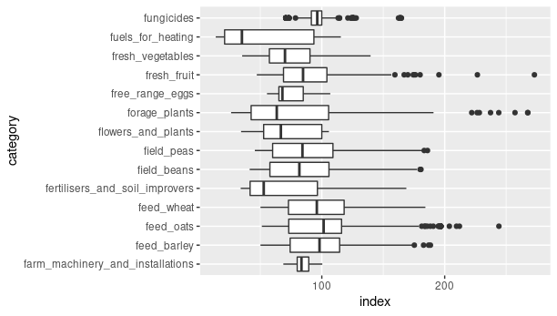

```r
## the tidyverse is pre-installed, so you can load it directly without installing it:
library(tidyverse)

## Now load the data:
prices <- read_csv("/dbfs/mnt/migrated-landing/General Access/AgriPricing/API-csv-10dec20.csv")

## Investigate the data:
head(prices)

## Only retain rows where variable category begins with an f:
prices <- filter(prices, str_detect(category, "^f"))

## Create an output:
ggplot(data = prices, aes(x = category, y = index)) +
  geom_boxplot() +
  coord_flip()

## Save the output:
ggsave("figure1.png")
```

[figure not shown]

You can also export files by ticking the box left to the file name, then More > Export…, and the file will be downloaded into your Downloads folder on your local machine.

## Saving data from RStudio to CDAP

To save your data into the lab zone of CDAP, you first need to create your own folder that you can save data to, which will in the unrestricted data folder in the lab zone. This means anyone can access your data there, so do not use this for restricted data.

Use the following line of code to create your folder, but replace the email address with your own Defra or ALB email address:

```r
dir.create("/dbfs/mnt/lab/unrestricted/firstname.lastname@defra.gov.uk")
```

You can test that this worked, by saving the `prices` file into your folder:

```r
write_csv(prices, "/dbfs/mnt/lab/unrestricted/firstname.lastname@defra.gov.uk/prices.csv")
```

To not clog up your data folder, you can delete the prices file:

```r
unlink("/dbfs/mnt/lab/unrestricted/firstname.lastname@defra.gov.uk/prices.csv")
```

You can go back to the **Data** section in Databricks and check that your folder is there, and whether the csv file has been saved and removed successfully.

## Uploading files into your RStudio workspace

[video not shown]

- You can upload your own files directly into your R workspace on CDAP.
- On the right hand side under Files, select **Upload**.
- In the pop-up, select **Choose file**, and then find your local file to upload.

The file will appear under the R folder in Files, or you can create your own folders in here and save the file to that folder. Uploading files in this way is useful for example for images that you want to insert into RMarkdown files.

The files you load into your R workspace are not backed up, therefore it is recommended that you back them up in some way, for example via GitHub.

Please do not use this uploading option for data that you need to work with regularly, but save it into your folder in the lab zone instead. Saving data that you only need for one session, for example for doing a training course, should be Ok however.

https://github.com/Defra-Data-Science-Centre-of-Excellence/CDAP_training.git